# Passerina caerulea sub species

Francisco Vega Reyes

2026-03-19

# Subspecies of Blue Grosbeak and its potential use for Motus tags

This is an evaluation of the sub-species of Blue Grosbeak (*Passerina caerulea*) and its potential use as model species for Oaxacan Central Valleys. Most information comes from Birds Of the World https://birdsoftheworld.org/bow/species/blugrb1/cur/introduction and the publication from Storer and Zimmerman (1959) https://deepblue.lib.umich.edu/items/24824b17-6f43-4b56-9ad8-64da66786885.

Currently, 6 sub-species have been recognized, their infromation about morphometrics and distribution is summarized on this table:

From these species, 2 or maybe 3 could be found in Oaxaca. These are *caerulea, interfusa and eurhyncha*.

| Sub especie | Region | Breeding | Wintering | Wing length mean (mm) | Wing length range | Tail length mean | Tail length range | Culmen length mean | Culmen length range | Body mass mean | Body mas range |
| --- | --- | --- | --- | --- | --- | --- | --- | --- | --- | --- | --- |
| caerulea | Eastern North America | Nebraska, Pensilvania, Texas, South Carolina | Greater antilles, E & S México, Panama | 88.36000 | 85 - 92 | 66.75333 | 63-73.5 | 12.44333 | 11.3 - 13.7 | NA | NA |
| interfusa | Western North America and México | Nevada, Colorado, Sonora, Chihuahua | Sonora, Jalisco and Valley of México | 89.70667 | 86.5 - 94 | 69.58667 | 66 - 75 | 12.24000 | 11.1 - 14 | NA | NA |
| eurhyncha | México | México, Guanajuato, SLP, Northern? Oaxaca | NA | 94.17400 | 90 - 96 | 74.37000 | 70 - 80 | 12.94800 | 12.1 - 13.7 | NA | NA |
| eurhyncha | Oaxaca (n = 2) | Oaxaca (9 and 20mi Southeast Oaxaca) | NA | 95.50000 | 95-96 | 75.00000 | 74 - 76 | 13.30000 | 12.9 - 13.7 | NA | NA |

#### Based on measurements we could tell appart individuals(?)

But the distribution of *interfusa* and *eurhyncha* for **Oaxacan Central Valleys** do not seem to overlap…

## Blue Grosbeaks in Oaxaca

To evaluate the status and trends in detail I requested a status and trends passcode

“Tu clave de estatus y tendencias:

4inq4qjs1326”

But there are changes on relative abundances happening throughout the Central Valleys. Whether is because of individuals of *interfusa* arriving from México and the US of individuals of *eurhyncha* conducting local movements, we do not know.

## Info from Xenocanto

API key is: 956e69561845a0f69d3f17b40e8b89ca00834788 956e69561845a0f69d3f17b40e8b89ca00834788

#### Recordings from Oaxaca in Xenocanto

**IN RED IS THE BREEDING RANGE**

> THIS INCLUDE THE INFORMATION ONLY FROM BREEDING TIME (MAY TO AUG)

```
## ℹ Obtaining metadata:
```

```
## ✔ 299 matching sound files found 🎊
```

```
##   repository format     key            species       date  time
## 1 Xeno-Canto  sound 1031007 Passerina caerulea 2025-08-19 08:45
## 2 Xeno-Canto  sound 1029633 Passerina caerulea 2025-08-16 06:29
## 3 Xeno-Canto  sound 1025817 Passerina caerulea 2025-07-26 08:54
## 4 Xeno-Canto  sound 1007730 Passerina caerulea 2025-06-19 06:00
## 5 Xeno-Canto  sound  971958 Passerina caerulea 2023-06-11 04:26
## 6 Xeno-Canto  sound  971956 Passerina caerulea 2023-07-05 04:39
##            user_name       country
## 1   Manuel Grosselet        Mexico
## 2   Manuel Grosselet        Mexico
## 3   Manuel Grosselet        Mexico
## 4     Scott Crabtree United States
## 5 Richard E. Webster United States
## 6 Richard E. Webster United States
##                                                          locality latitude
## 1      Santo Domingo Tomaltepec, Santo Domingo Tomaltepec, Oaxaca  17.0721
## 2                    Santa María Acuitlapilco, Tlaxcala, Tlaxcala  19.2783
## 3                Teotitlán del Valle, Teotitlán del Valle, Oaxaca  17.0285
## 4                                    Tucson, Pima County, Arizona  32.2690
## 5                                                 Portal, Arizona  31.9060
## 6 Leslie Canyon National Wildlife Refuge, Cochise County, Arizona  31.5910
##   longitude                                file_url file_extension
## 1  -96.6086 https://xeno-canto.org/1031007/download            wav
## 2  -98.2280 https://xeno-canto.org/1029633/download            wav
## 3  -96.5073 https://xeno-canto.org/1025817/download            wav
## 4 -110.8830 https://xeno-canto.org/1007730/download            wav
## 5 -109.1543  https://xeno-canto.org/971958/download            mp3
## 6 -109.5080  https://xeno-canto.org/971956/download            wav
```

[interactive chart not shown]

#### Recordings worldwide in Xenocanto

*NOTE:* EACH STATE HAS A DIFFERENT COLOR (IDEALLY…) >THIS INCLUDE THE INFORMATION ONLY FROM BREEDING TIME (MAY TO AUG)

**IN RED IS THE BREEDING RANGE**

[interactive chart not shown]

### Recordings worldwide from the Macaulay library

*NOTE:*EACH COLOR CORRESPONDS TO A DIFFERENT STATE

> THIS INCLUDE THE INFORMATION ONLY FROM BREEDING TIME (MAY TO AUG)

**IN RED IS THE BREEDING RANGE**

[interactive chart not shown]

## BLUE GROSBEAKS AUDIOS

Here is information from the Macaulay library. I selected audios from each locality between June and August. All songs selected include at least 2 *trill* elements

The information of the audios goes as follows:

### Oaxaca (eurhyncha)

#### Resident

*ML640535448*

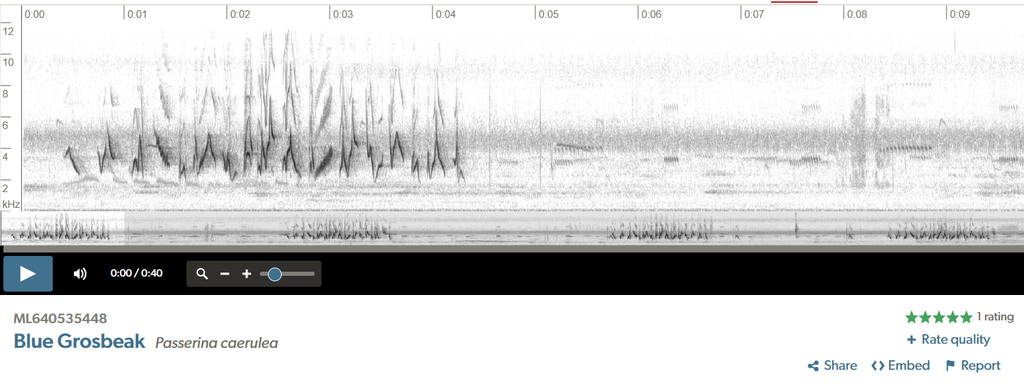

*ML622186110*

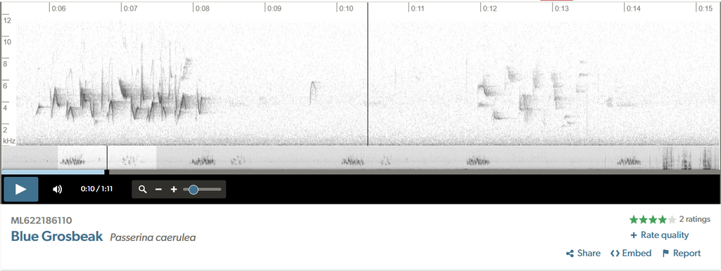

ML622186110

*ML255479461*

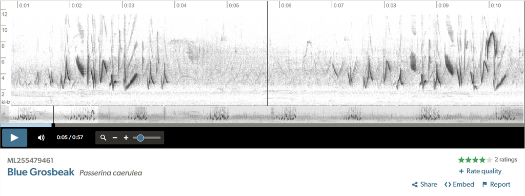

ML255479461

*ML636797365*

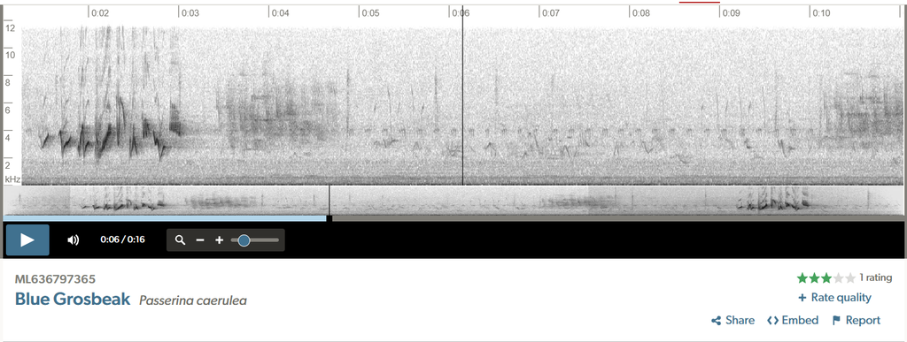

ML636797365

### NEW MEX, COLORADO(interfusa)

#### West Migrant

*ML550323781*

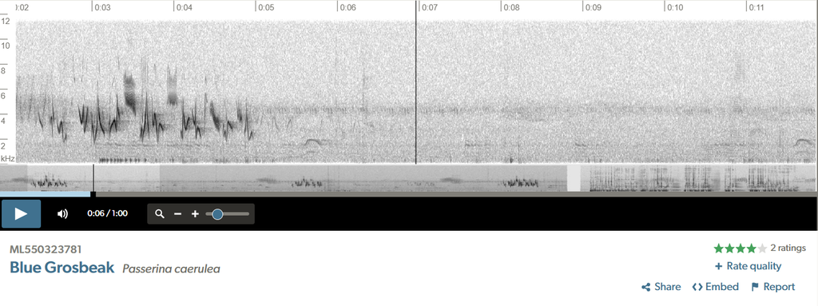

ML550323781

*ML562328101*

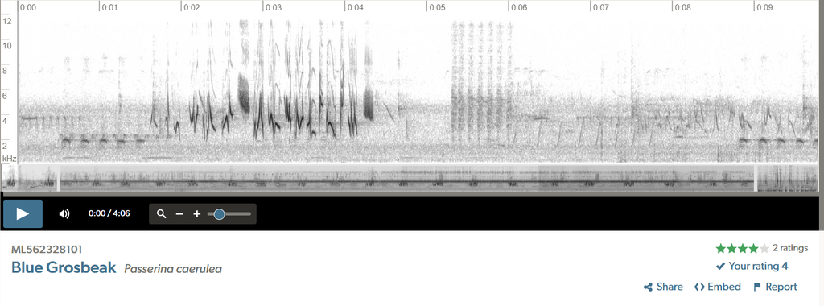

ML562328101

*ML67756551*

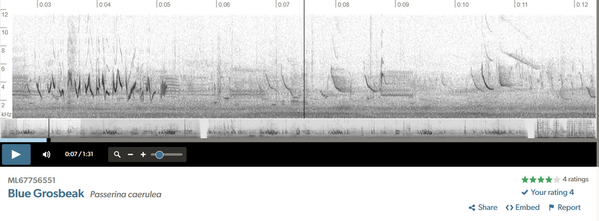

ML67756551

*ML465652321*

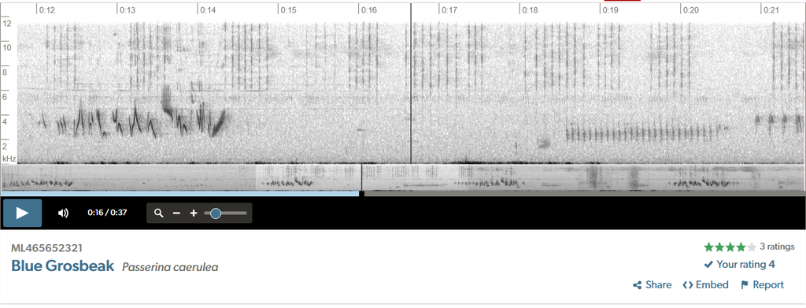

ML465652321

### PEN, SOUTH CAROLINA (caerulea)

#### East migrant

*ML621600823*

[figure not shown]

ML621600823

*ML621003816*

[figure not shown]

ML621003816

*ML248063861*

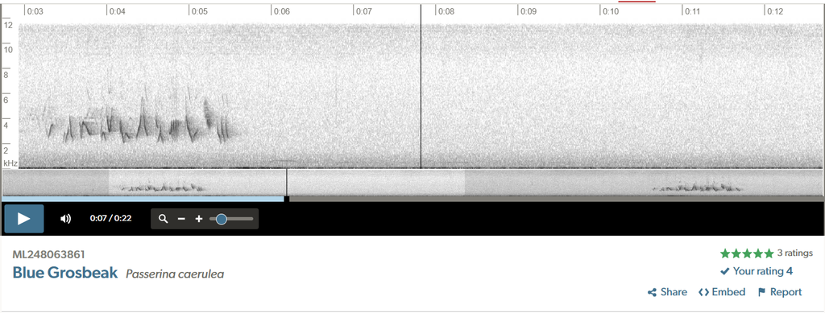

ML248063861

*ML350040061*

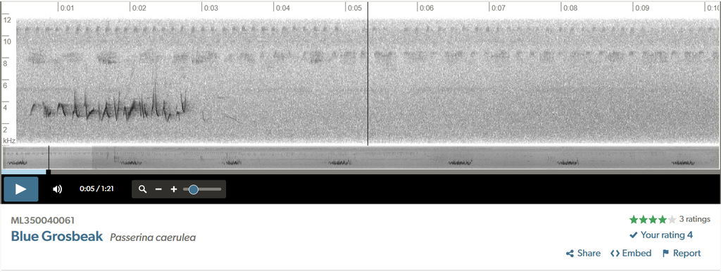

ML350040061